# Reproducible Research Project 1

## Loading and preprocessing the data

```r
library(knitr)
library(lubridate)
library(lattice)
```

1. Load the data.

```r
if(file.exists('activity.csv')){
  unzip('activity.zip')
}
activity<-read.csv("activity.csv", header = TRUE)
head(activity)
```

```
##   steps       date interval
## 1    NA 2012-10-01        0
## 2    NA 2012-10-01        5
## 3    NA 2012-10-01       10
## 4    NA 2012-10-01       15
## 5    NA 2012-10-01       20
## 6    NA 2012-10-01       25
```

2. Process the data.

```r
activity$date<-ymd(activity$date)
```

## What is the mean total number of steps taken per day?

1.Calculate the total number of steps per day.

```r
sumActivity<-aggregate(steps ~ date, data = activity, sum, na.rm = TRUE)
```

2. Make a histogram of the total number of steps taken each day.

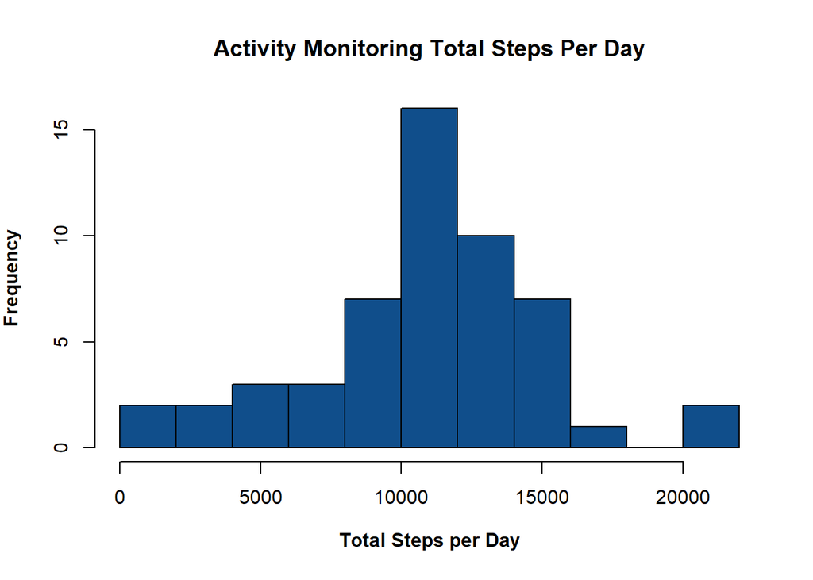

```r
hist(sumActivity$steps, 10, main = "Activity Monitoring Total Steps Per Day",
     xlab = expression(bold("Total Steps per Day")),
     ylab = expression(bold(Frequency)),col = "dodgerblue4")
```

```r
stepsMean<-mean(sumActivity$steps)
stepsMedian<-median(sumActivity$steps)
```

## What is the average daily activity pattern?

```r
aggAct<- aggregate(activity$steps ~ activity$interval, activity, mean, na.rm = T)
```

1. Make a time series plot.

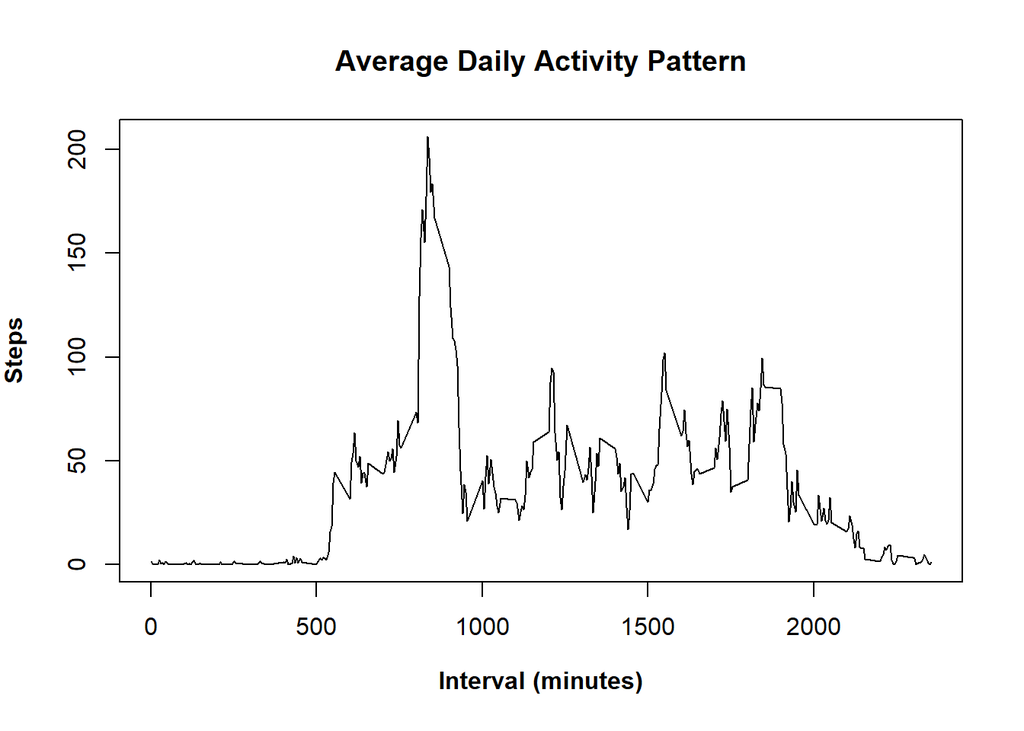

```r
plot(aggAct, type = "l", xlab = expression(bold("Interval (minutes)")),
     ylab = expression(bold("Steps")), main = "Average Daily Activity Pattern")
```

```r
maxInterval<- aggAct[which.max(aggAct$steps), ]
```

## Inputing missing values

```r
rowsNA<-sum(is.na(activity$steps))
```

2. Devise a strategy for filling in all of the missing values in the dataset.
3. Create a new dataset that is equal to the original dataset, but with the missing data filled in.

```r
activity2<-activity
NAs<-is.na(activity2$steps)
meanInterval<-with(activity2, tapply(steps, interval, mean, na.rm = T, simplify = TRUE))
activity2$steps[NAs]<-meanInterval[as.character(activity2$interval[NAs])]
```

4. Make a histogram of the total number of steps taken each day…

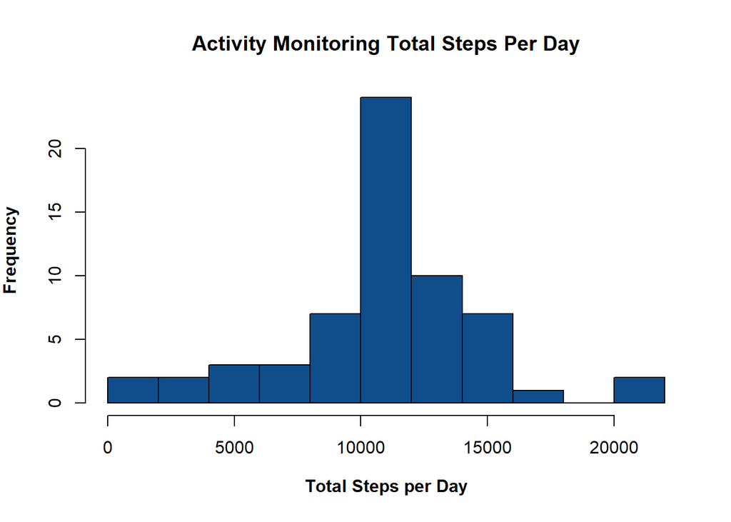

```r
sumActivity2<-with(activity2, tapply(steps, date, sum))
dSumAct2<-data.frame(Date = names(sumActivity2), Steps = sumActivity2)
hist(dSumAct2$Steps, 10, main = "Activity Monitoring Total Steps Per Day",
      xlab = expression(bold("Total Steps per Day")),
      ylab = expression(bold(Frequency)),col = "dodgerblue4")
```

```r
stepsMean2<-mean(dSumAct2$Steps)
stepsMedian2<-median(dSumAct2$Steps)
```

## Are there any differences in activity patterns between weekdays and weekends?

1. Create a new factor variable in the dataset with two levels - “weekend” and “weekday”.

```r
activity2$day<- weekdays(activity2$date)
activity2$week<- ""
activity2[activity2$day == "Saturday" | activity2$day == "Sunday",]$week<-"weekend"
activity2[!(activity2$day == "Saturday" | activity2$day == "Sunday"),]$week<-"weekday"
```

2. Make a panel plot containing the time series of the 5-minute interval (x-axis) and the average number of steps taken, averaged across all weekday or weekend days(y-axis).

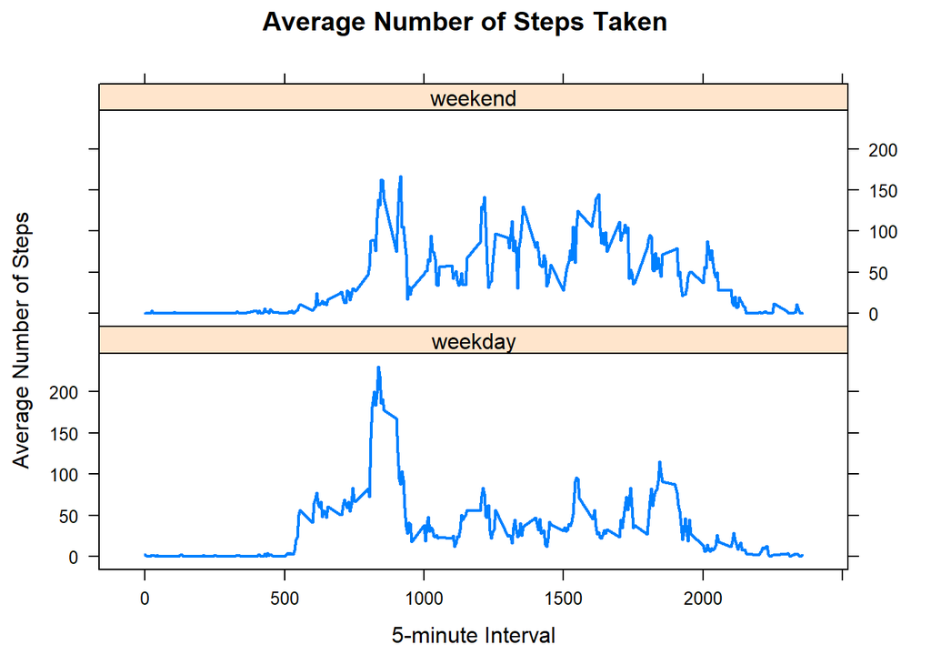

```r
aveStepActivity2<- aggregate(steps ~ interval + week, data = activity2, mean)
xyplot(steps ~ interval|week, data = aveStepActivity2, type = "l", lwd = 2,            layout = c(1,2),
       xlab = "5-minute Interval",
       ylab = "Average Number of Steps",
       main = "Average Number of Steps Taken")
```